# Nitrogen isotopes and land-use sources of coastal nitrate

## 2.2 Source covariates, islands and watersheds

```r
ag_cess <- cor.test(water_iso$pct_agriculture, water_iso$log_cess_exposure, method = "spearman", exact = FALSE)
cat("Agriculture vs cesspool exposure (isotope samples): Spearman rho =", round(ag_cess$estimate, 2),
    ", p =", signif(ag_cess$p.value, 2), "\n")
```

```
Agriculture vs cesspool exposure (isotope samples): Spearman rho = 0.11 , p = 0.21
```

```r
cat("Isotope samples with agriculture < 1%:", sum(water_iso$pct_agriculture < 0.01),
    "of", nrow(water_iso), "| with cesspool exposure index = 0:", sum(water_iso$cess_exposure_idx == 0), "\n")
```

```
Isotope samples with agriculture < 1%: 64 of 138 | with cesspool exposure index = 0: 11
```

```r
water_iso |>
  group_by(island) |>
  summarise(n = n(), n_ahupuaa = n_distinct(ahupuaa), median_d15N = median(N15), sd_d15N = sd(N15)) |>
  knitr::kable(digits = 2, caption = "d15N by island.")
```

d15N by island.

| island | n | n_ahupuaa | median_d15N | sd_d15N |
| --- | --- | --- | --- | --- |
| O’ahu | 73 | 29 | 8.40 | 3.17 |
| Maui | 52 | 18 | 8.30 | 3.12 |
| Moloka’i | 12 | 8 | 9.35 | 3.52 |
| Lāna’i | 1 | 1 | 9.30 | NA |

```r
# Between-watershed vs residual variation, after island
vc_dat <- water_iso |> mutate(ahup = factor(ahupuaa_key))
vc <- gam(N15 ~ island + s(ahup, bs = "re"), data = vc_dat, method = "REML")
vc_tab <- gam.vcomp(vc, conf.lev = 0.95)
```

```
Standard deviations and 0.95 confidence intervals:

         std.dev    lower    upper
s(ahup) 1.856194 1.073536 3.209445
scale   2.750872 2.342198 3.230853

Rank: 2/2
```

```r
cat("\nSD of d15N between ahupua'a (random intercept, after island): ",
    round(vc_tab[1, "std.dev"], 2), " [", round(vc_tab[1, "lower"], 2), ", ", round(vc_tab[1, "upper"], 2),
    "]; residual SD: ", round(vc_tab[2, "std.dev"], 2), "\n", sep = "")
```

```
SD of d15N between ahupua'a (random intercept, after island): 1.86 [1.07, 3.21]; residual SD: 2.75
```

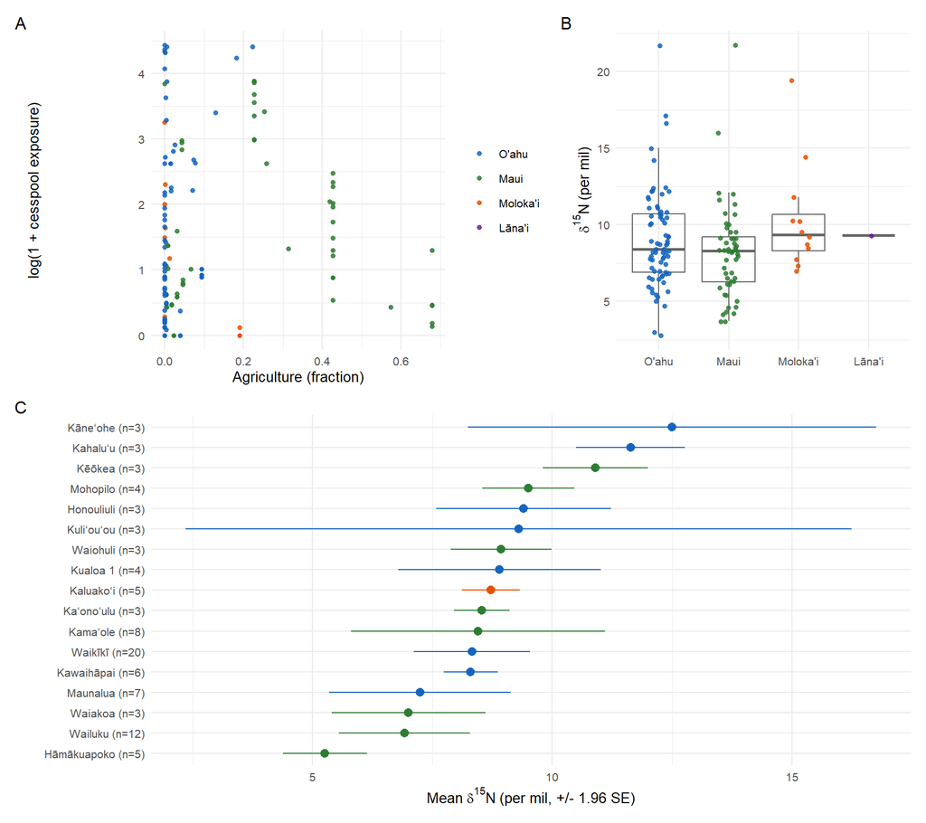

Figure 5

```r
p_agcess <- ggplot(water_iso, aes(pct_agriculture, log_cess_exposure, color = island)) +
  geom_point(alpha = 0.85) +
  scale_color_manual(values = island_pal, name = NULL) +
  labs(x = "Agriculture (fraction)", y = "log(1 + cesspool exposure)", tag = "A") +
  theme_minimal(base_size = 10)
p_island <- ggplot(water_iso, aes(island, N15, color = island)) +
  geom_boxplot(outlier.shape = NA, fill = NA, color = "gray40") +
  geom_jitter(width = 0.15, alpha = 0.85) +
  scale_color_manual(values = island_pal, guide = "none") +
  labs(x = NULL, y = expression(delta^{15}*N~"(per mil)"), tag = "B") +
  theme_minimal(base_size = 10)
ahup_sum <- water_iso |>
  group_by(island, ahupuaa) |>
  filter(n() >= 3) |>
  summarise(n = n(), mean = mean(N15), se = sd(N15) / sqrt(n()), .groups = "drop") |>
  mutate(lab = paste0(ahupuaa, " (n=", n, ")"))
p_ahup <- ggplot(ahup_sum, aes(mean, reorder(lab, mean), color = island)) +
  geom_pointrange(aes(xmin = mean - 1.96 * se, xmax = mean + 1.96 * se)) +
  scale_color_manual(values = island_pal, name = NULL) +
  labs(x = expression(Mean~delta^{15}*N~"(per mil, +/- 1.96 SE)"), y = NULL, tag = "C") +
  theme_minimal(base_size = 10) + theme(legend.position = "none")
(p_agcess | p_island) / p_ahup + plot_layout(heights = c(1, 1.1))
```

## 2.3 Does d15N respond to rainfall differently along the cesspool and agriculture gradients?

The plots split samples at the median of each land-use variable for display only; the models use the continuous standardized predictors (GAM z-scores), island as a fixed effect and an ahupua’a random intercept. With 138 samples, 56 ahupua’a and 35 ahupua’a with a single sample, these models are underpowered for interactions.

```r
int_dat <- water_iso |> mutate(ahup = factor(ahupuaa_key))
int_cess <- gam(N15 ~ z_chirps_storm_cumulative_mm * z_log_cess_exposure + island + s(ahup, bs = "re"),
                data = int_dat, method = "REML")
int_ag <- gam(N15 ~ z_chirps_storm_cumulative_mm * z_pct_agriculture + island + s(ahup, bs = "re"),
              data = int_dat, method = "REML")
int_both <- gam(N15 ~ z_chirps_storm_cumulative_mm * z_log_cess_exposure +
                  z_chirps_storm_cumulative_mm * z_pct_agriculture + island + s(ahup, bs = "re"),
                data = int_dat, method = "REML")
int_tab <- imap_dfr(list(cesspool_only = int_cess, agriculture_only = int_ag, both = int_both), \(m, nm) {
  pt <- summary(m)$p.table
  tibble(model = nm, term = rownames(pt), estimate = pt[, 1], se = pt[, 2],
         lwr = estimate - 1.96 * se, upr = estimate + 1.96 * se, p = pt[, 4])
}) |>
  filter(str_detect(term, "^z_"))
write_csv(int_tab, here("output", "isotope", "tables", "d15N_exploratory_interaction_models.csv"))
int_tab |>
  knitr::kable(digits = 3, caption = "d15N (per mil) per SD of predictor; island fixed, ahupua'a random intercept. Normal-approximation 95% intervals.")
```

d15N (per mil) per SD of predictor; island fixed, ahupua’a random intercept. Normal-approximation 95% intervals.

| model | term | estimate | se | lwr | upr | p |
| --- | --- | --- | --- | --- | --- | --- |
| cesspool_only | z_chirps_storm_cumulative_mm | 0.033 | 0.666 | -1.272 | 1.339 | 0.960 |
| cesspool_only | z_log_cess_exposure | 0.630 | 0.385 | -0.125 | 1.384 | 0.105 |
| cesspool_only | z_chirps_storm_cumulative_mm:z_log_cess_exposure | 0.618 | 0.668 | -0.691 | 1.928 | 0.357 |
| agriculture_only | z_chirps_storm_cumulative_mm | 0.610 | 0.740 | -0.839 | 2.059 | 0.411 |
| agriculture_only | z_pct_agriculture | -0.523 | 0.590 | -1.679 | 0.634 | 0.377 |
| agriculture_only | z_chirps_storm_cumulative_mm:z_pct_agriculture | 0.259 | 1.019 | -1.738 | 2.256 | 0.800 |
| both | z_chirps_storm_cumulative_mm | 0.292 | 0.813 | -1.301 | 1.884 | 0.720 |
| both | z_log_cess_exposure | 0.600 | 0.380 | -0.145 | 1.344 | 0.117 |
| both | z_pct_agriculture | -0.458 | 0.597 | -1.629 | 0.712 | 0.444 |
| both | z_chirps_storm_cumulative_mm:z_log_cess_exposure | 0.542 | 0.656 | -0.744 | 1.827 | 0.411 |
| both | z_chirps_storm_cumulative_mm:z_pct_agriculture | 0.301 | 1.025 | -1.707 | 2.310 | 0.769 |

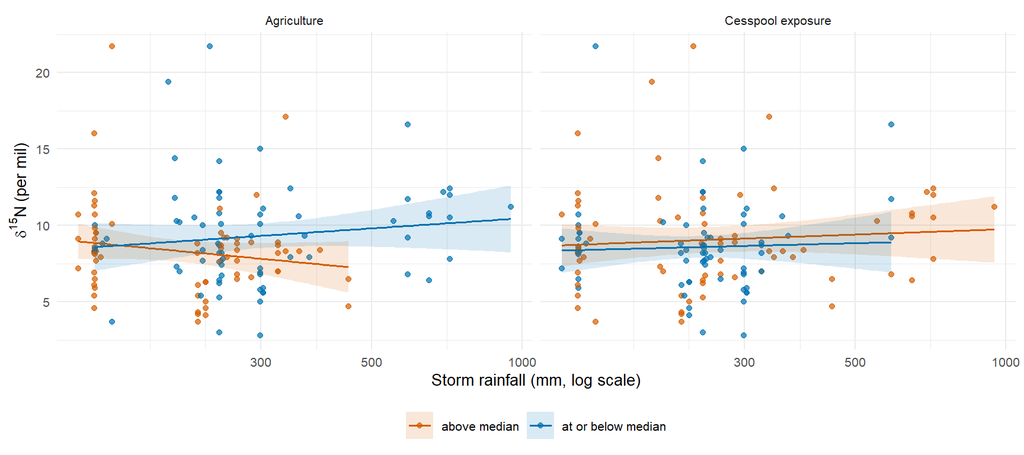

Figure 6

```r
split_dat <- water_iso |>
  mutate(`Cesspool exposure` = if_else(log_cess_exposure > median(log_cess_exposure), "above median", "at or below median"),
         `Agriculture` = if_else(pct_agriculture > median(pct_agriculture), "above median", "at or below median")) |>
  pivot_longer(c(`Cesspool exposure`, Agriculture), names_to = "gradient", values_to = "group")
ggplot(split_dat, aes(chirps_storm_cumulative_mm, N15, color = group, fill = group)) +
  geom_point(alpha = 0.7, size = 1.5) +
  geom_smooth(method = "lm", formula = y ~ x, linewidth = 0.7, alpha = 0.15) +
  facet_wrap(~gradient) +
  scale_x_log10() +
  scale_color_manual(values = c("above median" = "#D55E00", "at or below median" = "#0072B2"), name = NULL) +
  scale_fill_manual(values = c("above median" = "#D55E00", "at or below median" = "#0072B2"), name = NULL) +
  labs(x = "Storm rainfall (mm, log scale)", y = expression(delta^{15}*N~"(per mil)")) +
  theme_minimal(base_size = 10) + theme(legend.position = "bottom")
```